# GitHub for Strategic Analytics

2015-04-27

## Disclaimer

- This is **NOT** a tutorial on `Git` or `GitHub`.
- This is an overview of current setup for `GitHub Strategic Analytics`.
- Basic knowledge of `Git` is required to understand this document.

## General Information

- BCG GitHub: http://github.bcg.com/
- IP Address: [10.88.54.210](http://github.bcg.com/)
- GitHub for Strategic Analytics: http://github.bcg.com/strategic-analytics
- Admin: Greg Allen, Kirk Zmijewski, Boxuan Cui
- Resources:
  - [Full Documentation](http://git-scm.com/doc)
  - [5-minute Guide](http://rogerdudler.github.io/git-guide/)
  - [Git 101](http://www.slideshare.net/phpguru/git-101-31908275)

## Current Architecture

A repository can be either **public** or **private**, either **personal** or **organizational**.

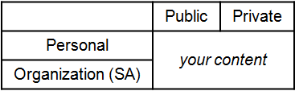

## Current Architecture

Example of repositories:

- Organizational public: general **Strategic Analytics** content with no privacy concerns, e.g., [SA Team Site](http://github.bcg.com/strategic-analytics/team-site), [Tier 1 Cases](http://github.bcg.com/strategic-analytics/20150113-orkin-google)
- Organizational private: case work that should not be visible to people outside **Strategic Analytics**, e.g., [B2B Pricing Suite](http://github.bcg.com/strategic-analytics/b2b-pricing-suite)
- Personal public: your personal playground like [Lunch Buddy](http://github.bcg.com/boc/lunch-buddy) and [Text Miner](http://github.bcg.com/boc/text-miner)
- Personal private: anything personal that you don't want people to see.

## Getting Started

To get started, download and install `git` from [git-scm](http://git-scm.com/download/win). Once installed, there are two ways to access the repositories on GitHub:

- Linux Bash: `Start -> All Programs -> Git -> Git Bash`
- GUI: `Start -> All Programs -> Git -> Git GUI`

## Creating a repository

To create a new repository, log in [GitHub](http://github.bcg.com/) and click the `+` sign from top right corner.

## Creating a repository

Choose if you want to create a personal/organizational, public/private repo and fill in the details.

[figure not shown]

## `Add -> Commit -> Push` (Git Bash)

Once repo is created, you can push your content with either `Git Bash`,

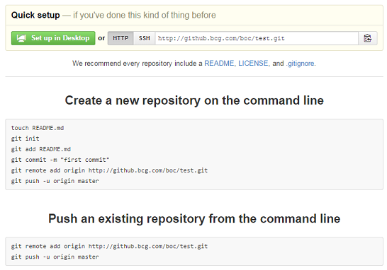

## `Add -> Commit -> Push` (Git GUI)

or `Git GUI`. (Click `Stage Changed -> Commit -> Push`)

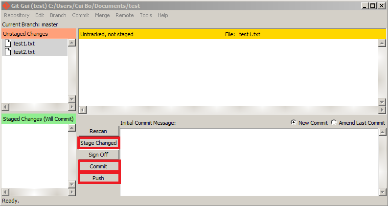

## Teams under Strategic Analytics

- Owner: Full admin, read & write access for administrators
- ca: Full admin, read & write access for customer analytics
- ga: Full admin, read & write access for geo-analytics
- everyone: Read access only for everyone

[figure not shown]

## Adding Collaborators

From your repo, you may add/revoke collaborators from `Settings -> Collaborators -> Add Team`.

[figure not shown]

## Reminders

- If you create a private repo (either personal or organizational), it is not visible until you add collaborators.
- Conversely, if you create a public repo (either personal or organizational), it is going to be visible to everyone. Pay close attention to sensitive information!
- Greg has a separate organization for **Meridian**, which has very different architecuture from **Strategic Analytics**. Please contact him directly if you want to mess with his stuff.
- I wonder who will read this s**t, so if you do, please let me know.